# DA 5020 Term Project

Yalim Demirkesen

December 4, 2017

# R CODE

The scraped data is stored in R:

```r
mydata <- read.csv("C:\\Users\\demir\\OneDrive\\NEU\\Fall 2017\\DA 5020\\Project\\Project\\Inpatient_Data_2011_CSV\\Medicare_Provider_Charge_Inpatient_DRG100_FY2011.csv")
```

Let’s check the quality of the data. Since it is from a govermental web site, I don’t expect any missing data. So preparation stage should be minimal. Let’s see whether every column runs as expected:

```r
na_matrix <- matrix(0, nrow = ncol(mydata), ncol = 1)
rownames(na_matrix) <- colnames(mydata)
colnames(na_matrix) <- c("NAs")
for(i in 1:ncol(mydata)){
  if(any(is.na(mydata[,i] == 'TRUE'))){
    na_matrix[i,1] <- 1
  }
}
na_matrix
```

```
##                                            NAs
## DRG.Definition                               0
## Provider.Id                                  0
## Provider.Name                                0
## Provider.Street.Address                      0
## Provider.City                                0
## Provider.State                               0
## Provider.Zip.Code                            0
## Hospital.Referral.Region..HRR..Description   0
## Total.Discharges                             0
## Average.Covered.Charges                      0
## Average.Total.Payments                       0
## Average.Medicare.Payments                    0
```

As we expected there is no NAs in any of the columns. What I did to compute this is first I started with creating a matrix with the name of “na_matrix” with one columns and as many as rows as the number of columns in my main dataset. Then with the help of an if function, I checked whether there are any NAs throughout the columns. If there are, corresponding row would have the value of 1. Since all the rows are 0, there is no NA in my dataset.

Let’s see the type of columns:

```r
str(mydata)
```

```
## 'data.frame':    163065 obs. of  12 variables:
##  $ DRG.Definition                            : Factor w/ 100 levels "039 - EXTRACRANIAL PROCEDURES W/O CC/MCC",..: 1 1 1 1 1 1 1 1 1 1 ...
##  $ Provider.Id                               : int  10001 10005 10006 10011 10016 10023 10029 10033 10039 10040 ...
##  $ Provider.Name                             : Factor w/ 3201 levels "ABBEVILLE GENERAL HOSPITAL",..: 2519 1499 730 2714 2445 158 687 2960 1133 882 ...
##  $ Provider.Street.Address                   : Factor w/ 3326 levels "#1 MEDICAL PARK DRIVE",..: 319 1494 1230 2291 87 1266 1165 2632 168 143 ...
##  $ Provider.City                             : Factor w/ 1977 levels "ABBEVILLE","ABERDEEN",..: 455 178 583 163 14 1152 1293 163 811 631 ...
##  $ Provider.State                            : Factor w/ 51 levels "AK","AL","AR",..: 2 2 2 2 2 2 2 2 2 2 ...
##  $ Provider.Zip.Code                         : int  36301 35957 35631 35235 35007 36116 36801 35233 35801 35903 ...
##  $ Hospital.Referral.Region..HRR..Description: Factor w/ 306 levels "AK - Anchorage",..: 3 2 2 2 2 6 2 2 4 2 ...
##  $ Total.Discharges                          : int  91 14 24 25 18 67 51 32 135 34 ...
##  $ Average.Covered.Charges                   : num  32963 15132 37560 13998 31633 ...
##  $ Average.Total.Payments                    : num  5777 5788 5435 5418 5658 ...
##  $ Average.Medicare.Payments                 : num  4764 4977 4454 4129 4851 ...
```

Everything seems fine here. The numbers are stated as integers or numbers and the strings are represented as factors.

Next step is storing our data in a relational database. Since we also have too many strings we may need a database that is document-oriented. So my choice is using mongoDB here. It will store the discharge values in a so called Binary JSON (BSON). After connecting to the server of mongoDB, we can start insterting the data to the mongoDB.

First I will create two different data frames since it will be much easier to store them like this. First one will include information about the providers; provider ID, provider name, address, zip code, state, city and in the second one information about the discharges; DRG definition, provider ID, provider name, total discharges, average covered charges, average total payments, average medicare payments.

```r
provider1 <- mydata[,2:8]
discharge1 <- mydata[,c(1,2,3,9,10,11,12)]
```

By the provider column I need to be sure that there is only one provider per row. There shouldn’t be more than one row for the same hospital.

```r
provider <- unique(provider1)
```

```r
nrow(provider1)-nrow(provider)
```

```
## [1] 159728
```

So there were almost 160000 duplicated values that we got rid of. Now the provider data, consists of entirely different rows.

And we need to do the same for the discharge.

```r
discharge <- unique(discharge1)
```

```r
nrow(discharge1)-nrow(discharge)
```

```
## [1] 0
```

It seems each row is already different from the other.

Just to visualize the two subdatasets:

```r
head(provider)
```

|  | Provider.Id | Provider.Name | Provider.Street.Address | Provider.City | Provider.State | Provider.Zip.Code | Hospital.Referral.Region..HRR..Description |
| --- | --- | --- | --- | --- | --- | --- | --- |
| 1 | 10001 | SOUTHEAST ALABAMA MEDICAL CENTER | 1108 ROSS CLARK CIRCLE | DOTHAN | AL | 36301 | AL - Dothan |
| 2 | 10005 | MARSHALL MEDICAL CENTER SOUTH | 2505 U S HIGHWAY 431 NORTH | BOAZ | AL | 35957 | AL - Birmingham |
| 3 | 10006 | ELIZA COFFEE MEMORIAL HOSPITAL | 205 MARENGO STREET | FLORENCE | AL | 35631 | AL - Birmingham |
| 4 | 10011 | ST VINCENT'S EAST | 50 MEDICAL PARK EAST DRIVE | BIRMINGHAM | AL | 35235 | AL - Birmingham |
| 5 | 10016 | SHELBY BAPTIST MEDICAL CENTER | 1000 FIRST STREET NORTH | ALABASTER | AL | 35007 | AL - Birmingham |
| 6 | 10023 | BAPTIST MEDICAL CENTER SOUTH | 2105 EAST SOUTH BOULEVARD | MONTGOMERY | AL | 36116 | AL - Montgomery |

```r
head(discharge)
```

|  | DRG.Definition | Provider.Id | Provider.Name | Total.Discharges | Average.Covered.Charges | Average.Total.Payments | Average.Medicare.Payments |
| --- | --- | --- | --- | --- | --- | --- | --- |
| 1 | 039 - EXTRACRANIAL PROCEDURES W/O CC/MCC | 10001 | SOUTHEAST ALABAMA MEDICAL CENTER | 91 | 32963.08 | 5777.242 | 4763.736 |
| 2 | 039 - EXTRACRANIAL PROCEDURES W/O CC/MCC | 10005 | MARSHALL MEDICAL CENTER SOUTH | 14 | 15131.86 | 5787.571 | 4976.714 |
| 3 | 039 - EXTRACRANIAL PROCEDURES W/O CC/MCC | 10006 | ELIZA COFFEE MEMORIAL HOSPITAL | 24 | 37560.38 | 5434.958 | 4453.792 |
| 4 | 039 - EXTRACRANIAL PROCEDURES W/O CC/MCC | 10011 | ST VINCENT'S EAST | 25 | 13998.28 | 5417.560 | 4129.160 |
| 5 | 039 - EXTRACRANIAL PROCEDURES W/O CC/MCC | 10016 | SHELBY BAPTIST MEDICAL CENTER | 18 | 31633.28 | 5658.333 | 4851.444 |
| 6 | 039 - EXTRACRANIAL PROCEDURES W/O CC/MCC | 10023 | BAPTIST MEDICAL CENTER SOUTH | 67 | 16920.79 | 6653.806 | 5374.149 |

Then the data is created in mongoDB and its inserted to the database.

```r
library(mongolite)
providerDB <- mongo(collection = "provider", db = "healthcare")
dischargeDB <- mongo(collection = "discharge", db = "healthcare")
mydataDB <- mongo(collection = "mydata", db = "healthcare")
```

```r
str(providerDB)
```

```
## Classes 'mongo', 'jeroen', 'environment' <environment: 0x00000000212837b0>
```

```r
str(dischargeDB)
```

```
## Classes 'mongo', 'jeroen', 'environment' <environment: 0x000000001866c8c8>
```

```r
str(mydataDB)
```

```
## Classes 'mongo', 'jeroen', 'environment' <environment: 0x00000000183f68d8>
```

```r
providerDB$insert(provider)
```

```
## List of 5
##  $ nInserted  : num 3337
##  $ nMatched   : num 0
##  $ nRemoved   : num 0
##  $ nUpserted  : num 0
##  $ writeErrors: list()
```

```r
dischargeDB$insert(discharge)
```

```
## List of 5
##  $ nInserted  : num 163065
##  $ nMatched   : num 0
##  $ nRemoved   : num 0
##  $ nUpserted  : num 0
##  $ writeErrors: list()
```

```r
mydataDB$insert(mydata)
```

```
## List of 5
##  $ nInserted  : num 163065
##  $ nMatched   : num 0
##  $ nRemoved   : num 0
##  $ nUpserted  : num 0
##  $ writeErrors: list()
```

Now we can start with some queries with the help of mongoDB:

```r
providerDB$count()
```

```
## [1] 13348
```

```r
dischargeDB$count()
```

```
## [1] 652260
```

# QUERIES

Number of hospitals in MA:

```r
providerDB$count('{"Provider_State":"MA"}')
```

```
## [1] 240
```

The state with most number of hospitals:

```r
vec1 <- providerDB$aggregate('[{"$group":{"_id":"$Provider_State", "count": {"$sum":1}}}]')
head(vec1[with(vec1, order(-count)),],10)
```

|  | _id | count |
| --- | --- | --- |
| 5 | TX | 1240 |
| 40 | CA | 1196 |
| 49 | FL | 664 |
| 12 | NY | 644 |
| 9 | PA | 604 |
| 10 | OH | 528 |
| 26 | IL | 512 |
| 33 | GA | 428 |
| 14 | TN | 388 |
| 50 | AL | 372 |

If we need any healthcare facility around Northeastern University, we need to visit following hospitals:

```r
providerDB$find('{"Provider_City":"BOSTON"}')
```

|  | Provider_Id | Provider_Name | Provider_Street_Address | Provider_City | Provider_State | Provider_Zip_Code | Hospital_Referral_Region__HRR__Description |
| --- | --- | --- | --- | --- | --- | --- | --- |
| 1 | 220071 | MASSACHUSETTS GENERAL HOSPITAL | 55 FRUIT STREET | BOSTON | MA | 2114 | MA - Boston |
| 2 | 220086 | BETH ISRAEL DEACONESS MEDICAL CENTER | 330 BROOKLINE AVENUE | BOSTON | MA | 2215 | MA - Boston |
| 3 | 220110 | BRIGHAM AND WOMEN'S HOSPITAL | 75 FRANCIS STREET | BOSTON | MA | 2115 | MA - Boston |
| 4 | 220116 | TUFTS MEDICAL CENTER | 800 WASHINGTON STREET | BOSTON | MA | 2111 | MA - Boston |
| 5 | 220017 | CARNEY HOSPITAL | 2100 DORCHESTER AVENUE | BOSTON | MA | 2124 | MA - Boston |
| 6 | 220031 | BOSTON MEDICAL CENTER CORPORATION | 1 BOSTON MEDICAL CENTER PLACE | BOSTON | MA | 2118 | MA - Boston |
| 7 | 220119 | FAULKNER HOSPITAL | 1153 CENTRE STREET | BOSTON | MA | 2130 | MA - Boston |
| 8 | 220088 | NEW ENGLAND BAPTIST HOSPITAL | 125 PARKER HILL AVENUE | BOSTON | MA | 2120 | MA - Boston |
| 9 | 220071 | MASSACHUSETTS GENERAL HOSPITAL | 55 FRUIT STREET | BOSTON | MA | 2114 | MA - Boston |
| 10 | 220086 | BETH ISRAEL DEACONESS MEDICAL CENTER | 330 BROOKLINE AVENUE | BOSTON | MA | 2215 | MA - Boston |

[output cut: 22 more lines]

It would be also good to know how much is the average coverage of the hospital to its overall costs. Depending on this value the patients or the insurance companies will be influenced. Less the coverage gets, more patients will get charged.

```r
vec2 <- mydataDB$aggregate('[{"$group":{"_id":"$Provider_State", "avg": {"$avg":"$Average_Covered_Charges"}}}]')
head(vec2[with(vec2, order(-avg)),],10)
```

|  | _id | avg |
| --- | --- | --- |
| 40 | CA | 67508.62 |
| 15 | NJ | 66125.69 |
| 48 | NV | 61047.12 |
| 49 | FL | 46016.24 |
| 5 | TX | 41480.20 |
| 45 | AZ | 41200.07 |
| 37 | CO | 41095.14 |
| 51 | AK | 40348.75 |
| 34 | DC | 40116.67 |
| 9 | PA | 39633.96 |

So we can say that California is the state with the highest on average coverage for healthcare charges in the US.

Let’s see California’s average total payment by the US Government. Total coverage being high may be caused by low average total payment. For this purpose, we might need a ggplot function.

```r
vec3 <- mydataDB$aggregate('[{"$group":{"_id":"$Provider_State", "avg": {"$avg":"$Average_Total_Payments"}}}]')
colnames(vec3) <- c("ID","Average")
```

Now for the plot:

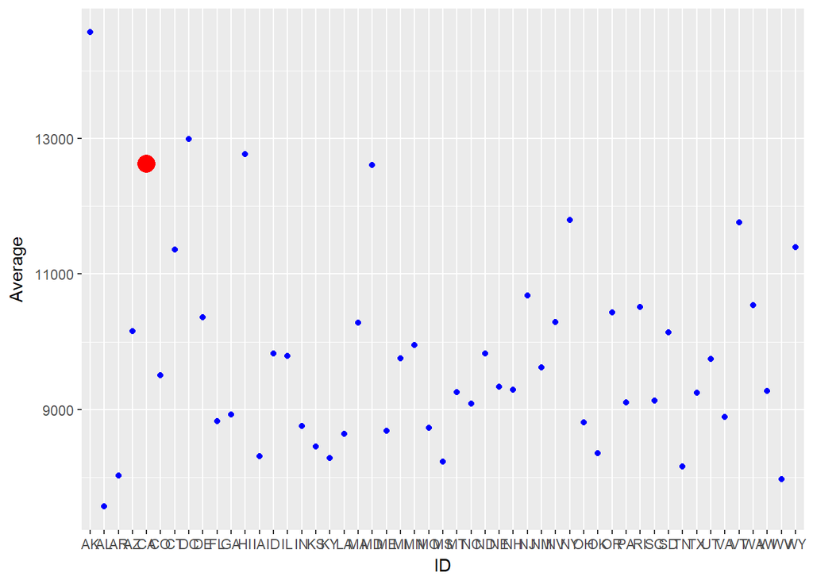

```r
library(ggplot2)
ggplot(vec3, aes(x = ID, y = Average)) +
  geom_point(colour="blue") +
  geom_point(data=vec3[40, ], aes(x=ID, y=Average), colour="red", size=5)
```

As we can see from the graph, actually the average total payment to California is one of the biggest. To be more precise it is in top 5. This graph helps us to understand that our theory is wrong. So is it the opposite? Is it so that the reason of US Government to pay them more is the high amount that the hospitals should cover by themselves?

To see that we need to check couple of more examples. In the above graph we see that Alaska is the state with highest total payment average. Also we remember that Alaska is also the 8th state in respect to the high coverage rate. We can prove that high coverage amount leads to high total payment if we can one example on the other side. AL is the state with the lowest total payment average. Is it because it has also the lowest average covered charges?

```r
tail(vec2[with(vec2, order(-avg)),],20)
```

|  | _id | avg |
| --- | --- | --- |
| 27 | IN | 28144.72 |
| 21 | MN | 27894.37 |
| 32 | OR | 27390.12 |
| 38 | DE | 27071.70 |
| 16 | NH | 27059.03 |
| 46 | AR | 26174.53 |
| 2 | WI | 26149.33 |
| 30 | ID | 25565.55 |
| 17 | NC | 25140.96 |
| 4 | UT | 25092.81 |

[output cut: 10 more lines]

When we print out the 20 states with the lowest average covered charges, Alabama is not amongst them. So we cannot see the correlation from here. The last option that we can do is to create a linear regression model to see the influence of average covered amount on average total payment.

```r
model <- lm(Average.Total.Payments ~ Total.Discharges + Average.Covered.Charges + Average.Medicare.Payments,
            data = mydata)
summary(model)
```

```
##
## Call:
## lm(formula = Average.Total.Payments ~ Total.Discharges + Average.Covered.Charges +
##     Average.Medicare.Payments, data = mydata)
##
## Residuals:
##    Min     1Q Median     3Q    Max
##  -7672   -401   -172     98  74741
##
## Coefficients:
##                            Estimate Std. Error t value Pr(>|t|)
## (Intercept)               8.263e+02  4.841e+00  170.70   <2e-16 ***
## Total.Discharges          7.797e-01  5.345e-02   14.59   <2e-16 ***
## Average.Covered.Charges   7.159e-03  1.218e-04   58.77   <2e-16 ***
## Average.Medicare.Payments 1.011e+00  5.844e-04 1730.31   <2e-16 ***
## ---
## Signif. codes:  0 '***' 0.001 '**' 0.01 '*' 0.05 '.' 0.1 ' ' 1
##
## Residual standard error: 1103 on 163061 degrees of freedom
## Multiple R-squared:  0.9793, Adjusted R-squared:  0.9793
## F-statistic: 2.572e+06 on 3 and 163061 DF,  p-value: < 2.2e-16
```

To check another information, we consider all the cities in Connecticut. This time we will take into account the average medicare payments. To be able to benefit from the mongoDB, we created a new data frame just including the Connecticut hospitals. Then we inserted the data to our mongoDB database, which enabled us to use our queries.

```r
mydata_CT <- mydata[grep("CT", mydata$Provider.State), ]
mydata_CT_DB <- mongo(collection = "mydata_CT_DB", db = "healthcare")
str(mydata_CT_DB)
```

```
## Classes 'mongo', 'jeroen', 'environment' <environment: 0x00000000212d0bf8>
```

```r
mydata_CT_DB$insert(mydata_CT)
```

```
## List of 5
##  $ nInserted  : num 2011
##  $ nMatched   : num 0
##  $ nRemoved   : num 0
##  $ nUpserted  : num 0
##  $ writeErrors: list()
```

```r
vec4 <- mydata_CT_DB$aggregate('[{"$group":{"_id":"$Provider_City", "avg": {"$avg":"$Average_Medicare_Payments"}}}]')
colnames(vec4) <- c("ID","Average")
```

Below you can see the graph of the data points for each city in Connecticut. To give a better understanding, I drew a line representing the mean of the average medicare payment.

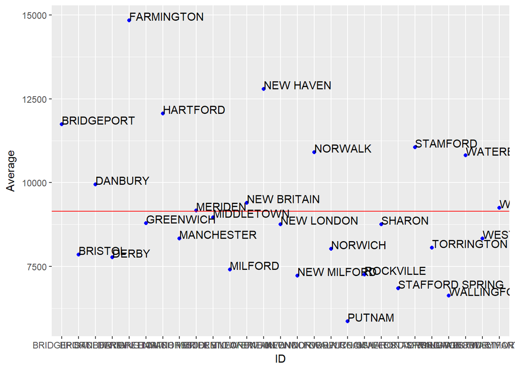

```r
library(ggplot2)
ggplot(vec4, aes(x = ID, y = Average)) +
  geom_point(colour="blue") +
  geom_hline(yintercept = mean(vec4$Average), color="red") +
  geom_text(aes(label=ID),hjust=0, vjust=0)
```

So we can say that in CT, Farmington is the city with the highest average medicare payment. Second comes the New Haven. On the other hand Putnam is the city in CT, that get least average medicare payment. This is a point to think about since the payment that Farmington gets is more than the doubled amount that Putnam gets.

As last I want to include analysis about the discharge of the patients. This number underlines how active a hospital is and depending on all the hospitals, it shows how active the city and state is. Depending on the result of this analysis, US government can consider adjusting the investment that it does in that certain location.

```r
vec5 <- mydataDB$aggregate('[{"$group":{"_id":"$Provider_Name","max":{"$max":"$Total_Discharges"}}}]')
head(vec5[with(vec5, order(-max)),],10)
```

|  | _id | max |
| --- | --- | --- |
| 384 | HOSPITAL FOR SPECIAL SURGERY | 3383 |
| 1855 | PARADISE VALLEY HOSPITAL | 1696 |
| 6 | ADCARE HOSPITAL OF WORCESTER INC | 1571 |
| 1318 | ST MARY & ELIZABETH MED CTR-DIVISION CAMPUS | 1487 |
| 78 | NEW ENGLAND BAPTIST HOSPITAL | 1464 |
| 2565 | FLORIDA HOSPITAL | 1344 |
| 2180 | NORTH SHORE MEDICAL CENTER | 1328 |
| 1804 | METHODIST HOSPITAL OF CHICAGO | 1264 |
| 2023 | WILLIAM BEAUMONT HOSPITAL | 1173 |
| 268 | MAYO CLINIC METHODIST HOSPITAL | 1124 |

Here we got an interesting outcome since the hospital with the most discharges is Hospital For Special Surgery. With the help of mongoDB, I will extract the location of thaat hospital.

```r
providerDB$find('{"Provider_Name":"HOSPITAL FOR SPECIAL SURGERY"}')
```

|  | Provider_Id | Provider_Name | Provider_Street_Address | Provider_City | Provider_State | Provider_Zip_Code | Hospital_Referral_Region__HRR__Description |
| --- | --- | --- | --- | --- | --- | --- | --- |
| 1 | 330270 | HOSPITAL FOR SPECIAL SURGERY | 535 EAST 70TH STREET | NEW YORK | NY | 10021 | NY - Manhattan |
| 2 | 330270 | HOSPITAL FOR SPECIAL SURGERY | 535 EAST 70TH STREET | NEW YORK | NY | 10021 | NY - Manhattan |
| 3 | 330270 | HOSPITAL FOR SPECIAL SURGERY | 535 EAST 70TH STREET | NEW YORK | NY | 10021 | NY - Manhattan |
| 4 | 330270 | HOSPITAL FOR SPECIAL SURGERY | 535 EAST 70TH STREET | NEW YORK | NY | 10021 | NY - Manhattan |

It seems that the loaction of the facility id in New York, NY. Let’s see the states with maximum hospital discharges.

```r
vec6 <- mydataDB$aggregate('[{"$group":{"_id":"$Provider_State","max":{"$max":"$Total_Discharges"}}}]')
colnames(vec6) <- c("ID","Max")
head(vec6[with(vec6, order(-Max)),],10)
```

|  | ID | Max |
| --- | --- | --- |
| 12 | NY | 3383 |
| 40 | CA | 1696 |
| 23 | MA | 1571 |
| 26 | IL | 1487 |
| 49 | FL | 1344 |
| 31 | MI | 1173 |
| 21 | MN | 1124 |
| 38 | DE | 1031 |
| 29 | OK | 1022 |
| 17 | NC | 991 |

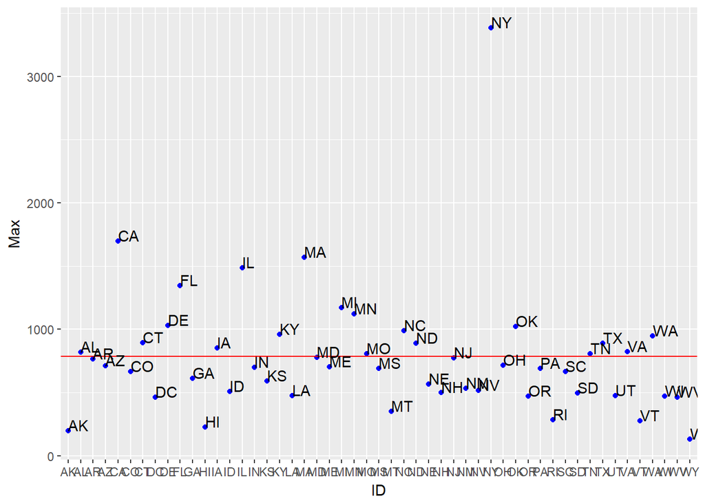

```r
library(ggplot2)
ggplot(vec6, aes(x = ID, y = Max)) +
  geom_point(colour="blue") +
  geom_hline(yintercept = mean(vec6$Max), color="red") +
  geom_text(aes(label=ID),hjust=0, vjust=0)
```

```r
vec7 <- mydataDB$aggregate('[{"$group":{"_id":"$Provider_Name","max":{"$max":"$Total_Discharges"}}}]')
colnames(vec7) <- c("ID","Max")
vec7 <- head(vec7[with(vec7, order(-Max)),],20)
```

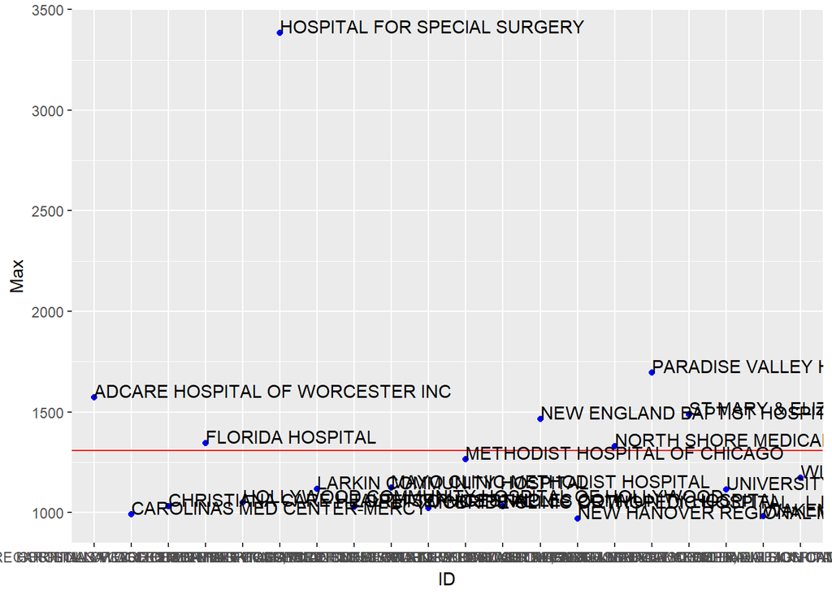

```r
library(ggplot2)
ggplot(vec7, aes(x = ID, y = Max)) +
  geom_point(colour="blue") +
  geom_hline(yintercept = mean(vec7$Max), color="red") +
  geom_text(aes(label=ID),hjust=0, vjust=0)
```